# **LAB 02 : K-MEANS CLUSTERING ON CALIFORNIA HOUSING DATA**

REGISTER NO: 23122024

CLASS : MSc-DS-A

### LAB OVERVIEW :

Perform KMeans Clustering on the previously given dataset itself.

In cluster analysis, features of the predicted clusters are looked into such that the properties of those clusters are then identified.

Demonstrate the usage of Elbow Method to find the Optimum Number of Cluster.

Additional Exploration: Make use of Clustering Visualisation Methods

#### THEORITICAL BACKGROUND :

K-means clustering is an unsupervised machine learning algorithm used to group similar data points into clusters.

K-means clustering aims to partition a dataset into K distinct, non-overlapping clusters. Each observation belongs to the cluster with the nearest mean (also known as the cluster center or centroid), which serves as a prototype for that cluster1.

It’s an iterative algorithm that divides an unlabeled dataset into K different clusters, ensuring that each data point belongs to only one group with similar properties.

K-means is particularly useful for discovering natural groupings within data without requiring any prior training or labeled examples. Working of KMeans Algorithm will be discussed in tomorrow's class.

**Choosing the Optimal K:**

Determining the right value of K is crucial. You can use techniques like the elbow method to find the optimal K. The elbow method involves plotting the sum of squared distances (variance) from each data point to its assigned centroid for different values of K. The “elbow” point on the plot indicates the optimal K, where adding more clusters doesn’t significantly reduce variance2

**BASIC EXPLORATORY DATA ANALYSIS**

```python
# Import libraries
import pandas as pd
import numpy as np
import matplotlib.pyplot as plt
import seaborn as sns

from sklearn.preprocessing import StandardScaler
from sklearn.cluster import KMeans
from itertools import cycle, islice
from pandas.plotting import parallel_coordinates
```

```python
df=pd.read_csv("housing.csv")
```

```python
df.info()
```

```
<class 'pandas.core.frame.DataFrame'>
RangeIndex: 20640 entries, 0 to 20639
Data columns (total 10 columns):
 #   Column              Non-Null Count  Dtype
---  ------              --------------  -----
 0   longitude           20640 non-null  float64
 1   latitude            20640 non-null  float64
 2   housing_median_age  20640 non-null  float64
 3   total_rooms         20640 non-null  float64
 4   total_bedrooms      20433 non-null  float64
 5   population          20640 non-null  float64
 6   households          20640 non-null  float64
 7   median_income       20640 non-null  float64
 8   median_house_value  20640 non-null  float64
 9   ocean_proximity     20640 non-null  object
dtypes: float64(9), object(1)
memory usage: 1.6+ MB
```

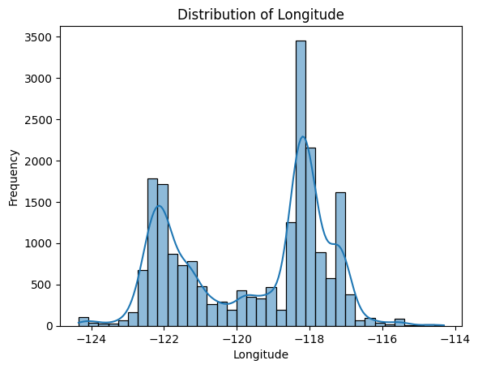

```python
sns.histplot(df['longitude'], kde=True)  # Use kde=True to include kernel density estimation
plt.title(f'Distribution of Longitude')
plt.xlabel("Longitude")
plt.ylabel('Frequency')
plt.show()
```

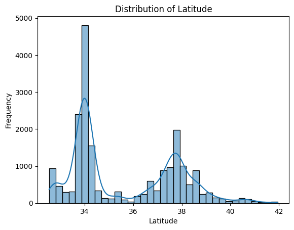

```python
sns.histplot(df['latitude'], kde=True)  # Use kde=True to include kernel density estimation
plt.title(f'Distribution of Latitude')
plt.xlabel("Latitude")
plt.ylabel('Frequency')
plt.show()
```

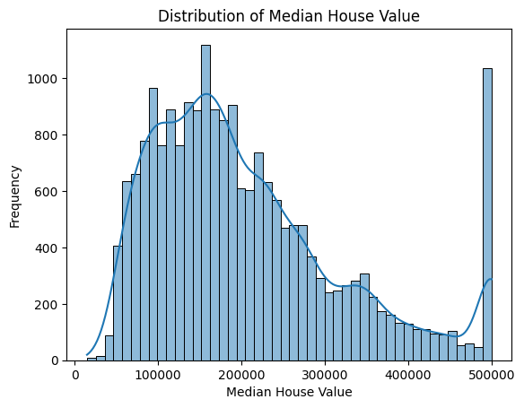

```python
sns.histplot(df['median_house_value'], kde=True)  # Use kde=True to include kernel density estimation
plt.title(f'Distribution of Median House Value')
plt.xlabel("Median House Value")
plt.ylabel('Frequency')
plt.show()
```

```python
features = ['longitude', 'latitude', 'median_income']
select_df = df[features]
select_df.columns
```

```
Index(['longitude', 'latitude', 'median_income'], dtype='object')
```

```python
# Scale the features
X = StandardScaler().fit_transform(select_df)
```

```python
X.shape
```

```
(20640, 3)
```

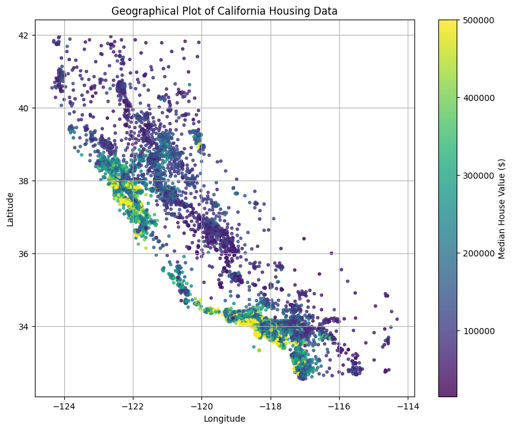

```python
# Plot the geographical data
plt.figure(figsize=(10, 8))
scatter = plt.scatter(df['longitude'], df['latitude'], c=df['median_house_value'], cmap='viridis', s=10, alpha=0.8)
plt.colorbar(scatter, label='Median House Value ($)')
plt.xlabel('Longitude')
plt.ylabel('Latitude')
plt.title('Geographical Plot of California Housing Data')
plt.grid(True)
plt.show()
```

**APPLYING K-MEANS CLUSTERING**

```python
kmeans_1 = KMeans(n_clusters=1) # number of clusters must be specified
model_1 = kmeans_1.fit(X)
model_1

# Get cluster labels
cluster_labels_1 = kmeans_1.labels_
cluster_labels_1
```

```
array([0, 0, 0, ..., 0, 0, 0])
```

```python
kmeans_2 = KMeans(n_clusters=2) # number of clusters must be specified
model_2 = kmeans_2.fit(X)
model_2

# Get cluster labels
cluster_labels_2 = kmeans_2.labels_
cluster_labels_2
```

```
array([1, 1, 1, ..., 1, 1, 1])
```

```python
kmeans_3 = KMeans(n_clusters=3) # number of clusters must be specified
model_3 = kmeans_3.fit(X)
model_3

# Get cluster labels
cluster_labels_3= kmeans_3.labels_
cluster_labels_3
```

```
array([2, 2, 2, ..., 2, 2, 2])
```

```python
kmeans_4 = KMeans(n_clusters=4) # number of clusters must be specified
model_4 = kmeans_4.fit(X)
model_4

# Get cluster labels
cluster_labels_4 = kmeans_4.labels_
cluster_labels_4
```

```
array([1, 1, 1, ..., 3, 3, 3])
```

```python
kmeans_5 = KMeans(n_clusters=5) # number of clusters must be specified
model_5= kmeans_5.fit(X)
model_5

# Get cluster labels
cluster_labels_5 = kmeans_5.labels_
cluster_labels_5
```

```
array([4, 4, 4, ..., 0, 0, 0])
```

```python
centers_1 = model_1.cluster_centers_
centers_1
```

```
array([[-8.98441528e-15,  6.17324882e-16, -8.00931242e-18]])
```

```python
centers_2 = model_2.cluster_centers_
centers_2
```

```
array([[ 0.78181474, -0.79193379,  0.02743583],
       [-1.07169505,  1.08556603, -0.03760845]])
```

```python
centers_3 = model_3.cluster_centers_
centers_3
```

```
array([[ 0.78633796, -0.78068451, -0.32456019],
       [ 0.50150801, -0.61126442,  1.88597127],
       [-1.07720601,  1.10081363, -0.13423179]])
```

```python
centers_4 = model_4.cluster_centers_
centers_4
```

```
array([[ 0.78898269, -0.77796491, -0.44026585],
       [-1.18834964,  0.95458925,  1.17435847],
       [ 0.7560276 , -0.82727579,  1.32873211],
       [-1.02822441,  1.13938384, -0.50583673]])
```

```python
centers_5 = model_5.cluster_centers_
centers_5
```

```
array([[-1.16575765,  1.243437  , -0.46009328],
       [-0.07983482,  0.21387822, -0.62262264],
       [ 0.75710132, -0.82704464,  1.36207295],
       [ 0.8602992 , -0.84742519, -0.40937286],
       [-1.19805905,  0.95650532,  1.22664683]])
```

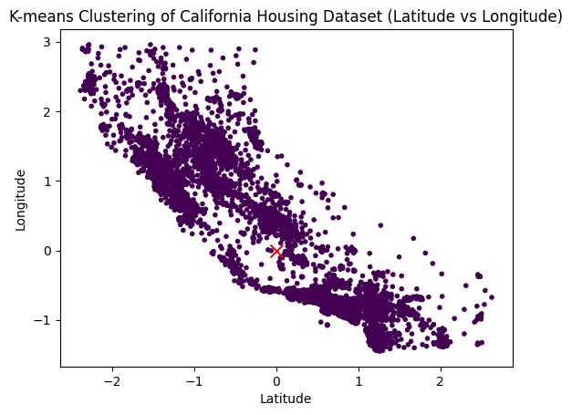

```python
# Visualize the clusters (for latitude and longitude)
plt.scatter(X[:, 0], X[:, 1], c=cluster_labels_1, cmap='viridis', marker='.')
plt.scatter(kmeans_1.cluster_centers_[:, 0], kmeans_1.cluster_centers_[:, 1], c='red', marker='x', s=100)
plt.xlabel('Latitude')
plt.ylabel('Longitude')
plt.title('K-means Clustering of California Housing Dataset (Latitude vs Longitude)')
plt.show()
```

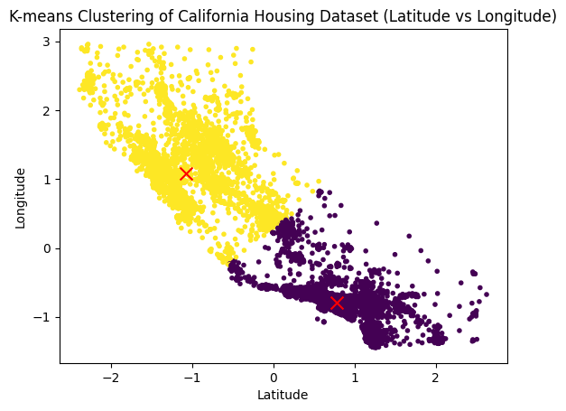

```python
# Visualize the clusters (for latitude and longitude)
plt.scatter(X[:, 0], X[:, 1], c=cluster_labels_2, cmap='viridis', marker='.')
plt.scatter(kmeans_2.cluster_centers_[:, 0], kmeans_2.cluster_centers_[:, 1], c='red', marker='x', s=100)
plt.xlabel('Latitude')
plt.ylabel('Longitude')
plt.title('K-means Clustering of California Housing Dataset (Latitude vs Longitude)')
plt.show()
```

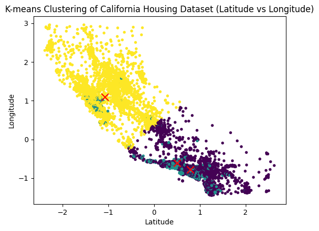

```python
# Visualize the clusters (for latitude and longitude)
plt.scatter(X[:, 0], X[:, 1], c=cluster_labels_3, cmap='viridis', marker='.')
plt.scatter(kmeans_3.cluster_centers_[:, 0], kmeans_3.cluster_centers_[:, 1], c='red', marker='x', s=100)
plt.xlabel('Latitude')
plt.ylabel('Longitude')
plt.title('K-means Clustering of California Housing Dataset (Latitude vs Longitude)')
plt.show()
```

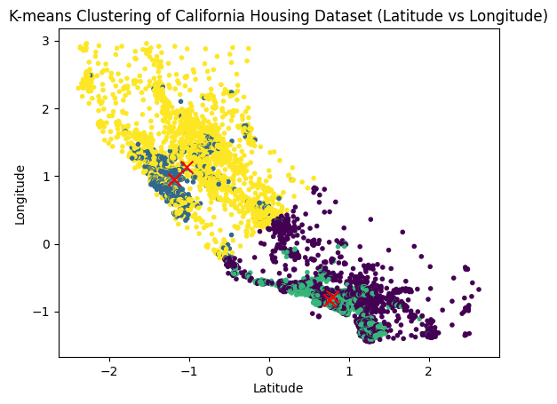

```python
# Visualize the clusters (for latitude and longitude)
plt.scatter(X[:, 0], X[:, 1], c=cluster_labels_4, cmap='viridis', marker='.')
plt.scatter(kmeans_4.cluster_centers_[:, 0], kmeans_4.cluster_centers_[:, 1], c='red', marker='x', s=100)
plt.xlabel('Latitude')
plt.ylabel('Longitude')
plt.title('K-means Clustering of California Housing Dataset (Latitude vs Longitude)')
plt.show()
```

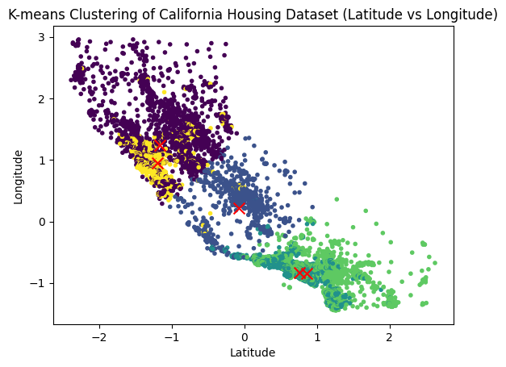

```python
# Visualize the clusters (for latitude and longitude)
plt.scatter(X[:, 0], X[:, 1], c=cluster_labels_5, cmap='viridis', marker='.')
plt.scatter(kmeans_5.cluster_centers_[:, 0], kmeans_5.cluster_centers_[:, 1], c='red', marker='x', s=100)
plt.xlabel('Latitude')
plt.ylabel('Longitude')
plt.title('K-means Clustering of California Housing Dataset (Latitude vs Longitude)')
plt.show()
```

```python
# Initialize lists to store intra-cluster distances
intra_cluster_distances = []

# Calculate intra-cluster distance for different number of clusters (1 to 5)
for n_clusters in range(1, 6):
    kmeans = KMeans(n_clusters=n_clusters, random_state=42)
    kmeans.fit(X)
    intra_cluster_distances.append(kmeans.inertia_)

# Print the intra-cluster distances
for i, distance in enumerate(intra_cluster_distances, start=1):
    print(f"Number of clusters: {i}, Intra-cluster distance: {distance}")
```

```
Number of clusters: 1, Intra-cluster distance: 61920.00000000003
Number of clusters: 2, Intra-cluster distance: 26860.98352093487
Number of clusters: 3, Intra-cluster distance: 18987.366223806835
Number of clusters: 4, Intra-cluster distance: 14547.724174848006
Number of clusters: 5, Intra-cluster distance: 12632.865174008304
```

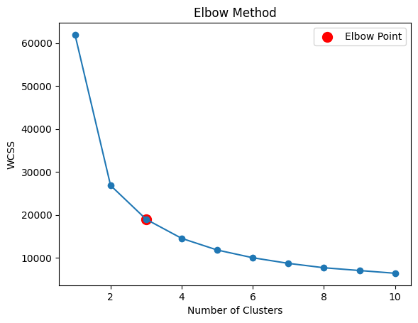

```python
# Extracting longitude, latitude, and median house value features
longitude = X[:, 0]  # Longitude
latitude = X[:, 1]  # Latitude
median_house_value = X[:, -1]  # Median house value

# Stack the features together
X_selected_features = np.column_stack((longitude, latitude, median_house_value))

# Calculate WCSS for different values of k
wcss = []
for i in range(1, 11):
    kmeans = KMeans(n_clusters=i, init='k-means++', max_iter=300, n_init=10, random_state=0)
    kmeans.fit(X_selected_features)
    wcss.append(kmeans.inertia_)

# Plot the elbow curve
plt.plot(range(1, 11), wcss, marker='o', linestyle='-')
plt.title('Elbow Method')
plt.xlabel('Number of Clusters')
plt.ylabel('WCSS')

# Highlight the elbow point with a dot
elbow_point = 3
plt.scatter(elbow_point, wcss[elbow_point - 1], c='red', s=100, label='Elbow Point')
plt.legend()

plt.show()
```

** CONCLUSION **

The optimized cluster size is 3.